# dmr-analysis

Ciel Baumann

2026-04-21

## DMR Analysis

### Load Environment

#### Install packages

```r
#install.packages("BiocManager")
#BiocManager::install('methylKit')
#BiocManager::install('genomation', force=TRUE)
```

#### Load libraries

```r
library(methylKit, quietly=TRUE)
library(GenomicRanges, quietly=TRUE)
library(genomation, quietly=TRUE) # Used for annotation of DMBs/DMRs
```

#### Load data files

The coverage files contain %-methylation score per base for each sample, and are output from the Bismark Aligner.

```r
# Get coverage file locations
cov_dir <- "../results/03_bismark_coverage/"
location_vector <- c() # List of locations of BAM files
all_files <- list.files(cov_dir, full.names = TRUE)
for (file in all_files){
  if (endsWith(file, ".cov.gz")){
    location_vector <- append(location_vector, file)
  }
}

# Get sample METADATA
METADATA <- read.csv("../data/SraRunTable.txt")
METADATA$file <- location_vector
FETAL_METADATA <- METADATA[METADATA$Age=="E21",]
NUM_SAMPLES <- nrow(FETAL_METADATA)

# Encode control as 0, hypoxic as 1
treatment_vector <- data.table::fifelse(FETAL_METADATA$treatment == 'control', 0, 1)

# Create initial methylraw object
meth_raw = methRead(location = as.list(FETAL_METADATA$file),
                    sample.id = as.list(FETAL_METADATA$Run),
                    assembly = "hg18",
                    context = "CpG",
                    treatment = treatment_vector,
                    pipeline = "bismarkCoverage",
                    mincov = 3)
```

```
## Received list of locations.
```

```
## Uncompressing file.
```

```
## Reading file.
```

```
## Uncompressing file.
```

```
## Reading file.
```

```
## Uncompressing file.
```

```
## Reading file.
```

```
## Uncompressing file.
```

```
## Reading file.
```

```
## Uncompressing file.
```

```
## Reading file.
```

```
## Uncompressing file.
```

```
## Reading file.
```

```r
# Remove obsolete environment variables
rm(all_files, cov_dir, location_list, file, treatment_vector)
```

Read in the gene BED file and CpG island annotation file to use for annotation later:

```r
# The gene data file is a .bed.txt.gz file
gene_data_path <- "../data/genome/Genes.bed.txt.gz"
GENE_DATA = readTranscriptFeatures(gene_data_path)
```

```
## Reading the table...
```

```
## Calculating intron coordinates...
```

```
## Calculating exon coordinates...
```

```
## Calculating TSS coordinates...
```

```
## Calculating promoter coordinates...
```

```
## Outputting the final GRangesList...
```

```r
# The CpG island annotation file is also a .bed.txt.gz file
shore_data_path <- "../data/genome/CpG.bed.txt.gz"
SHORE_DATA = readFeatureFlank(shore_data_path)

rm(gene_data_path, shore_data_path, METADATA)
```

### Clean Unmerged Data

#### Initial raw data exploration

##### View Histogram of % CpG methylation

If everything has been done right, there should be a peak at each end. This is because methylation is a one-or-none thing - a base is either methylated, or it is not. I don’t fully understand why the middle section shows anything, but imagine it is reflective of uncertainty in the analysis. The active code snippet below shows the histogram for the first sample only, but uncommenting the rest of the below code snippet shows that all samples follow the same distribution.

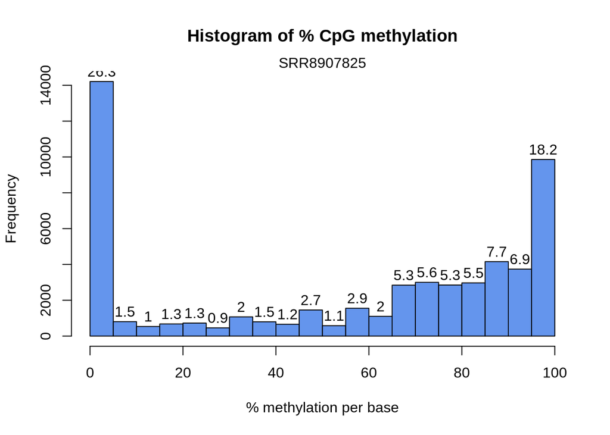

```r
# View % CpG methylation histogram for first sample only
getMethylationStats(meth_raw[[1]], plot=TRUE, both.strands=FALSE)
```

```r
# View histogram for each sample
#par(mfrow = c(NUM_SAMPLES/2, NUM_SAMPLES/2))
#for (sample_i in seq(1, NUM_SAMPLES)){
#  getMethylationStats(meth_raw[[sample_i]], plot = TRUE, both.strands = FALSE)
#}
```

##### View Histogram of CpG coverage on first sample

“Experiments highly suffering from PCR duplication bias will have a secondary peak towards the right hand side” (methylKit.Knit, n.d.). These samples do not appear to have this issue.

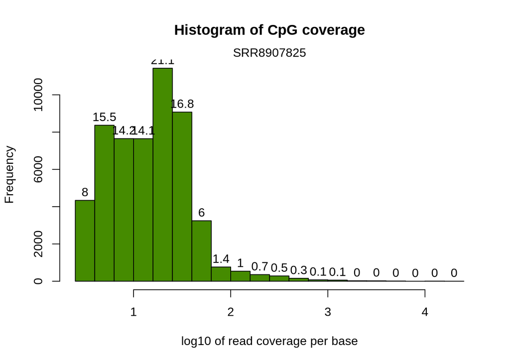

```r
# View CpG coverage histogram for first sample only
getCoverageStats(meth_raw[[1]], plot=TRUE, both.strands=FALSE)
```

```r
# View CpG coverage histogram for each sample - same distributions for all
#par(mfrow = c(NUM_SAMPLES/2, NUM_SAMPLES/2))
#for (sample_i in seq(1, NUM_SAMPLES)){
#  getCoverageStats(meth_raw[[sample_i]], plot=TRUE, both.strands=FALSE)
#}
#rm(sample_i)
```

#### Filter samples based on read coverage

If samples are suffering PCR duplication bias, it is useful to discard bases with very high read coverage (methylKit.Knit, n.d.). These samples do not appear to have this issue, but it doesn’t hurt to apply the upper filter anyway.

More relevant to this analysis is choosing a minimum read coverage. I originally used a (somewhat arbitrary) minimum read coverage of 10, but this value was far too restrictive, and I didn’t get any results. I toyed around with other smaller values but most were still too restrictive. In the end, I chose to use a minimum read coverage of 3, due to the very small sample size (3 samples per group). This averages out to one read per sample per group at minimum, which is still quite restrictive but not so much that I get no results.

```r
getCoverageStats(meth_raw[[1]], plot=FALSE, both.strands = FALSE)
```

```
## read coverage statistics per base
## summary:
##     Min.  1st Qu.   Median     Mean  3rd Qu.     Max.
##     3.00     7.00    15.00    30.95    27.00 23965.00
## percentiles:
##        0%       10%       20%       30%       40%       50%       60%       70%
##     3.000     4.000     6.000     8.000    11.000    15.000    19.000    24.000
##       80%       90%       95%       99%     99.5%     99.9%      100%
##    30.000    40.000    54.000   294.520   527.000  2089.808 23965.000
```

```r
MIN_READ_COVERAGE = 3
meth_filtered = filterByCoverage(meth_raw,
                                lo.count=MIN_READ_COVERAGE,
                                lo.perc=NULL,
                                hi.count=NULL,
                                hi.perc=99.9)
```

#### Normalise coverage values

This is only essential if the coverage is not similar across samples, but doesn’t hurt to include (methylKit.Knit, n.d.).

```r
meth_normalised = normalizeCoverage(meth_filtered, method = "median")
```

### Merge Samples and Filter Further

The unite function has a min.per.group option, which defaults to keeping only the bases/regions that are covered in all samples. I am using this default option as the sample size is very small, and adjusting this to a value smaller than 3 will decrease the power of this analysis (which already lacks power) even further.

The unite function also has a destrand option (default = FALSE). Using destrand = TRUE improves coverage by merging the reads on both strands of a CpG island (methylKit.Knit, n.d.). More coverage seems helpful in this case due to the small sample size, so I originally using destrand = TRUE. However, this is not compatible with the using the default min.per.group which I consider more important for the analysis, so I am using destrand = FALSE instead.

```r
#meth = unite(meth_filtered, destrand=TRUE) # No base united error
meth = unite(meth_filtered, destrand=FALSE)
```

```
## uniting...
```

```r
head(meth)
```

```
##   chr  start    end strand coverage1 numCs1 numTs1 coverage2 numCs2 numTs2
## 1  13 111504 111504      *         4      2      2         6      3      3
## 2  13 111541 111541      *         4      4      0         6      4      2
## 3  13 111570 111570      *         4      4      0         6      6      0
## 4  13 254518 254518      *        15      9      6        35     29      6
## 5  13 254758 254758      *       122     93     29       233    177     56
## 6  13 254762 254762      *       125     97     28       236    183     53
##   coverage3 numCs3 numTs3 coverage4 numCs4 numTs4 coverage5 numCs5 numTs5
## 1         4      3      1        10      7      3         3      2      1
## 2         4      2      2        10      7      3         3      1      2
## 3         4      4      0        10      6      4         3      3      0
## 4        17     12      5        18     15      3        22     16      6
## 5       107     84     23       190    146     44       161    130     31
## 6       108     85     23       192    149     43       163    132     31
##   coverage6 numCs6 numTs6
## 1         4      3      1
## 2         3      0      3
## 3         5      4      1
## 4        17     13      4
## 5       144    113     31
## 6       144    116     28
```

```r
# Remove obsolete methylkit objects from environment
rm(meth_normalised, meth_filtered, meth_raw)
```

#### Remove non-variable CpGs from merged dataset

“High-throughput methylation data contains a lot of CpG sites that have no or little variation among study subjects and are not all that informative for downstream analyses” (methylKit.Knit, n.d.). Standard deviation filtering on methylation ratio values “will lower the number of tests to be performed, thus reducing multiple correction penalities” (methylKit.Knit, n.d.).

The below histogram reveals a large peak on the left, which represents the CpG sites with no differential methylation in this analysis. To increase the power of this analysis and reduce multiple testing penalties, I am removing these CpG sites from the dataset.

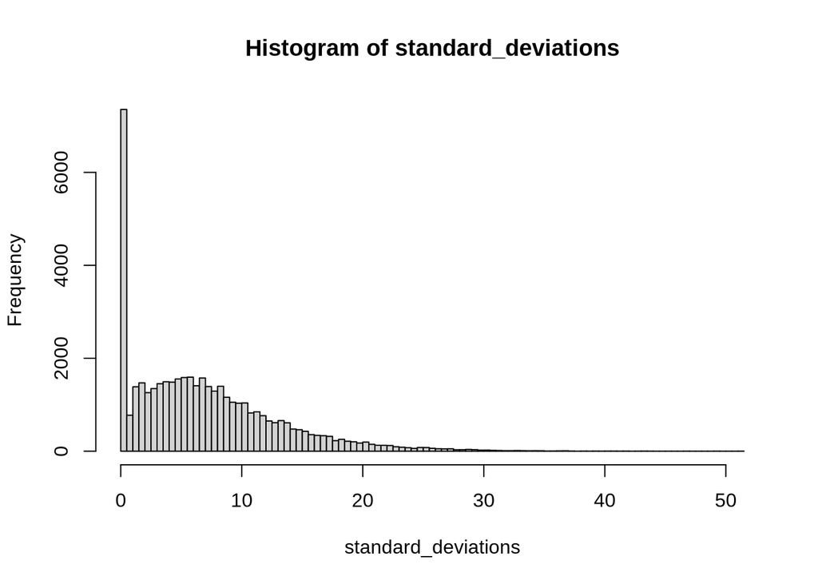

```r
# Get CpG standard deviations and visualise their distribution
standard_deviations <- matrixStats::rowSds(percMethylation(meth))
hist(standard_deviations, breaks = 100)
```

```r
# Keep only CpGs with standard deviations larger than 2%
meth <- meth[standard_deviations > 2]
nrow(meth)
```

```
## [1] 33625
```

```r
rm(standard_deviations)
```

#### Remove known C -> T mutations (if applicable) (SKIPPED)

This step is out of the scope of this analysis.

#### Check sample correlations and cluster based on methylation profile similarities

Looking at the correlation plot, each sample is fairly highly positively correlated regardless of group, showing similar methylation profiles across the board.

Looking at the PC1-PC2 plot: on the PC1 axis, the red sample on the right almost appears as though it could be an outlier, though with such a small sample size, it’s impossible to actually say. With the assumption the variation is the PC1 axis really is due to the red outlier, the PC2 axis appears more important, showing a potential cluster of blue samples at the bottom, and a potential cluster of red samples at the top. Although these clusters at first appear to be well defined, it is important to remember that there are only 3 samples per group, so this pattern could very easily be due to chance. If we re-ran this experiment with many more samples, these clusters could appear quite different and potentially overlap.

PC2 and PC3 appear to have similar importance, so I have generated a PC2-PC3 plot as well. Again, with so few samples, it’s impossible to really say much about this plot. The situation is very similar to the PC1-PC2 plot - if we treat the far left blue dot as a potential outlier, we can see there *may* be two clusters. However, this is probably just due to chance.

```
##            SRR8907825 SRR8907826 SRR8907827 SRR8907828 SRR8907829 SRR8907830
## SRR8907825  1.0000000  0.8926481  0.8590883  0.8892750  0.8704348  0.8673229
## SRR8907826  0.8926481  1.0000000  0.8759323  0.9055765  0.8873447  0.8864469
## SRR8907827  0.8590883  0.8759323  1.0000000  0.8766327  0.8557853  0.8558029
## SRR8907828  0.8892750  0.9055765  0.8766327  1.0000000  0.8907993  0.8884129
## SRR8907829  0.8704348  0.8873447  0.8557853  0.8907993  1.0000000  0.8687887
## SRR8907830  0.8673229  0.8864469  0.8558029  0.8884129  0.8687887  1.0000000
```

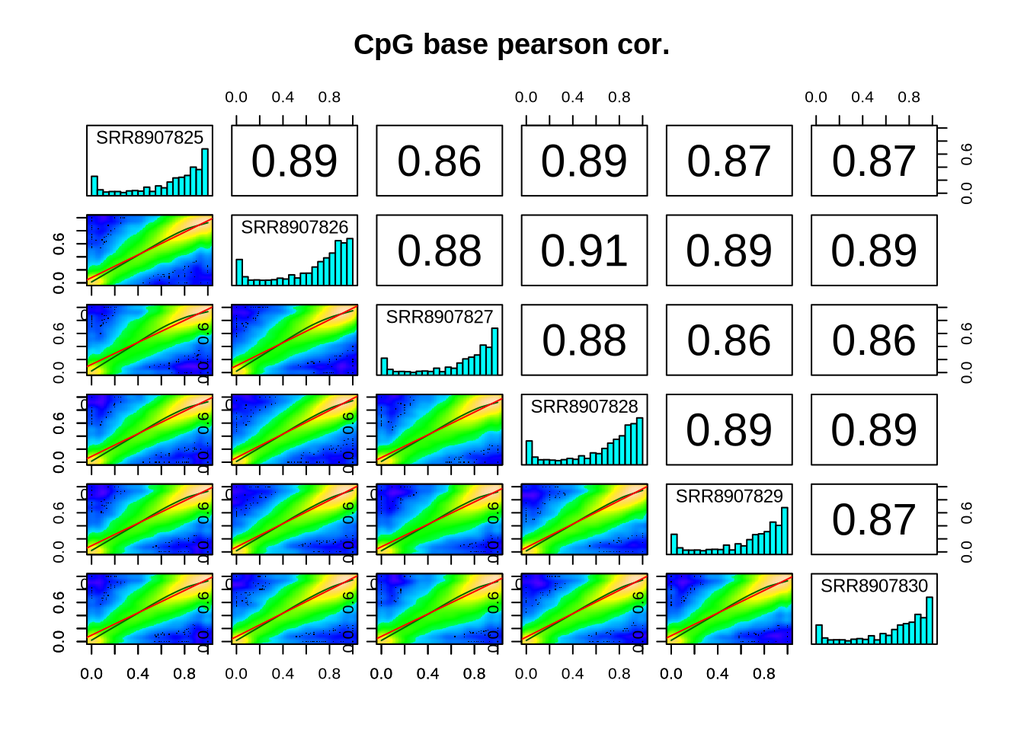

```r
# Check sample correlations
getCorrelation(meth, plot=TRUE) # high positive correlation between all samples
```

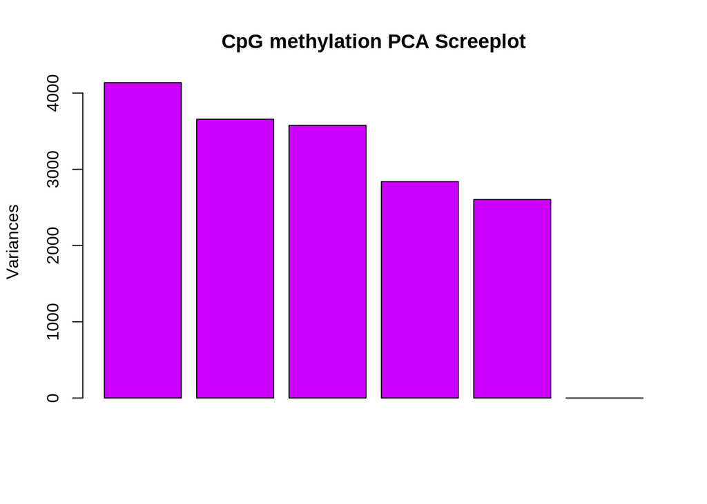

```r
# Generate PCA analysis scree plot to show component importances
PCASamples(meth, screeplot = TRUE)
```

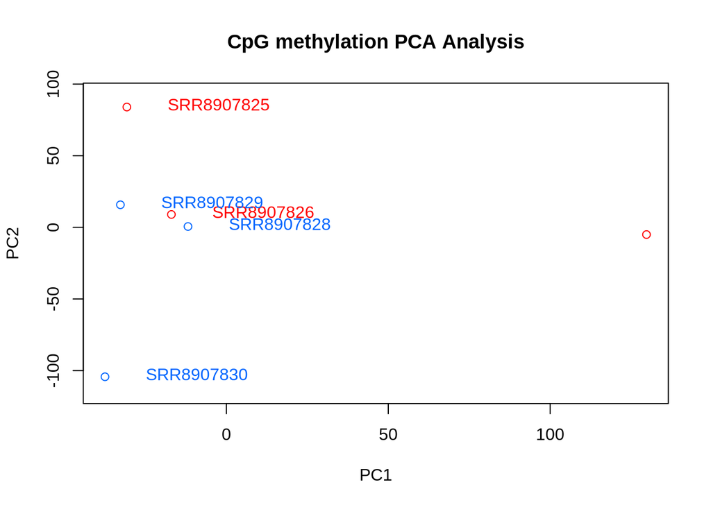

```r
PCASamples(meth, comp = c(1,2)) # View PC1 and PC2 axes
```

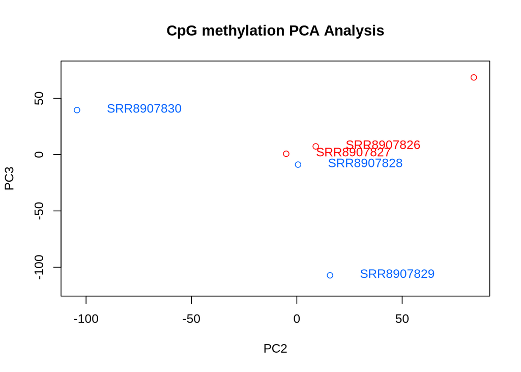

```r
PCASamples(meth, comp = c(2,3)) # View PC2 and PC3 axes
```

#### Accounting for batch effects (SKIPPED)

Not enough metadata.

### Finding DMBs/DMRs

Here I am computing the differential methylation p-values and q-values using an F-test. Using adjust=‘BH’ calculates the q-values (i.e., adjusted p-values) using the Benjamini-Hochberg adjustment. I am unsure if this dataset actually needs an overdispersion adjustment, but I can’t imagine it would hurt to include anyway since it’s just scaling the variance of the dataset so that the dataset has a constant variance, so I used overdispersion=“MN” to do so. Applying this overdispersion correction causes the computation to default to using an F-test, which I have no issue with.

```r
diffs = calculateDiffMeth(meth,
                          adjust = "BH",
                          overdispersion="MN")
```

```
## two groups detected:
##  will calculate methylation difference as the difference of
## treatment (group: 1) - control (group: 0)
```

```r
head(diffs)
```

```
##   chr  start    end strand     pvalue    qvalue  meth.diff
## 1  13 111504 111504      * 0.43641984 0.9815361  13.445378
## 2  13 111541 111541      * 0.42907399 0.9815361 -21.428571
## 3  13 111570 111570      * 0.01098831 0.8726870 -27.777778
## 4  13 254518 254518      * 0.73919426 0.9994933   2.566117
## 7  13 255019 255019      * 0.03750703 0.9682435  -5.720477
## 8  13 255054 255054      * 0.68486644 0.9994933  -1.295210
```

#### Select hyper-methylated bases, hypo-methylated bases, and all differentially methylated bases

Using q-value <= 0.01 and %-diff >= 25% gave me only one significant result, so I decided to relax these parameters slightly to a threshold of percent-methylation difference >= 20%, and q-value (adjusted p-value) <= 0.05. These values strike a balance between generosity and remaining sensible within the context of this analysis.

Overall, 4 CpG sites are significantly hypermethylated, and 6 are hypomethylated.

```r
diffs_hyper = getMethylDiff(diffs, difference=20, qvalue=0.05, type="hyper")
diffs_hypo = getMethylDiff(diffs, difference=20, qvalue=0.05, type="hypo")
diffs_all = getMethylDiff(diffs, difference=20, qvalue=0.05)

# View % of hypo/hyper methylated bases over all covered bases in a given chromosome.
diffMethPerChr(diffs, plot=FALSE, qvalue.cutoff=0.05, meth.cutoff=20)
```

```
## $diffMeth.per.chr
##   chr number.of.hypermethylated percentage.of.hypermethylated
## 1  13                         4                    0.01189591
##   number.of.hypomethylated percentage.of.hypomethylated
## 1                        6                   0.01784387
##
## $diffMeth.all
##   number.of.hypermethylated percentage.of.hypermethylated
## 1                         4                    0.01189591
##   number.of.hypomethylated percentage.of.hypomethylated
## 1                        6                   0.01784387
```

#### Annotate DMBs

```r
# Rename chr variable to ensure compatibility with annotation functions
diffs_all$chr="chr13"
diffs_hyper$chr="chr13"
diffs_hypo$chr="chr13"
```

```r
# Annotate hyper- and hypo-methylated gene parts (promoters, exons, introns, intergenic)
diffs_hyper_ann_parts <- annotateWithGeneParts(target=as(diffs_hyper, "GRanges"), feature=GENE_DATA)
diffs_hypo_ann_parts <- annotateWithGeneParts(target=as(diffs_hypo, "GRanges"), feature=GENE_DATA)

# Annotate hyper- and hypo-methylated CpG shores
diffs_hyper_ann_shores <- annotateWithFeatureFlank(target=as(diffs_hyper, "GRanges"),
                                                  feature=SHORE_DATA$features,
                                                  flank=SHORE_DATA$flanks,
                                                  feature.name="CpGi",
                                                  flank.name="shores")
diffs_hypo_ann_shores <- annotateWithFeatureFlank(target=as(diffs_hypo, "GRanges"),
                                                  feature=SHORE_DATA$features,
                                                  flank=SHORE_DATA$flanks,
                                                  feature.name="CpGi",
                                                  flank.name="shores")
```

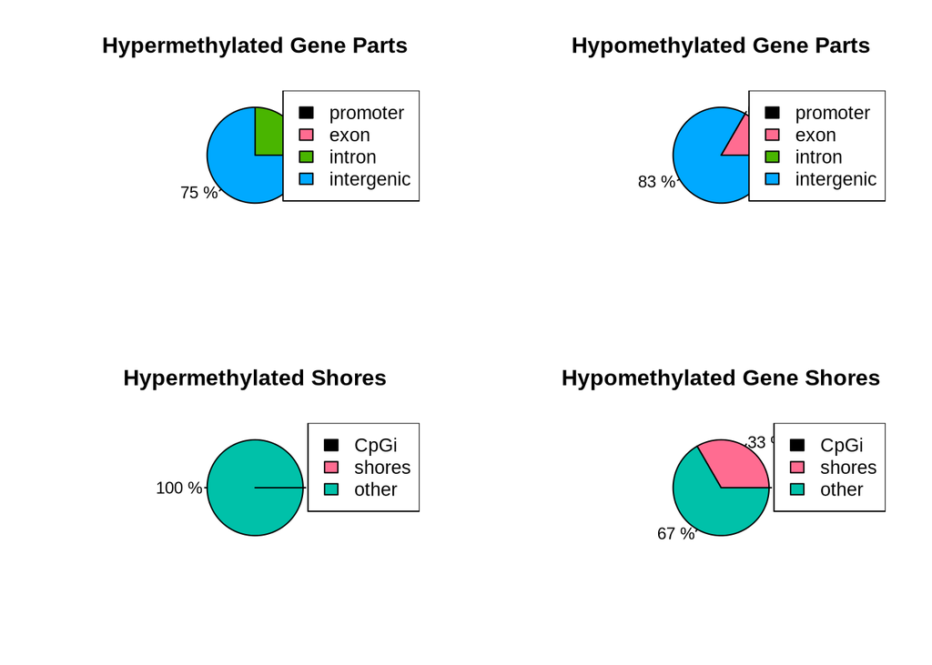

```r
# Plot annotations
par(mfrow = c(2,2))
plotTargetAnnotation(diffs_hyper_ann_parts, precedence = TRUE,
                     main = "Hypermethylated Gene Parts")
plotTargetAnnotation(diffs_hypo_ann_parts, precedence = TRUE,
                     main = "Hypomethylated Gene Parts")
plotTargetAnnotation(diffs_hyper_ann_shores, precedence = TRUE,
                     main = "Hypermethylated Shores")
plotTargetAnnotation(diffs_hypo_ann_shores, precedence = TRUE,
                     main = "Hypomethylated Gene Shores")
```

#### Summarise methylation info over different regions

There appear to be no regions in common between the groups?

```r
regionCounts(meth, GENE_DATA$exons) # No sequence levels in common warning - 0 rows
```

```
##  [1] chr       start     end       strand    coverage1 numCs1    numTs1
##  [8] coverage2 numCs2    numTs2    coverage3 numCs3    numTs3    coverage4
## [15] numCs4    numTs4    coverage5 numCs5    numTs5    coverage6 numCs6
## [22] numTs6
## <0 rows> (or 0-length row.names)
```

```r
regionCounts(meth, GENE_DATA$introns) # No sequence levels in common warning - 0 rows
```

```
##  [1] chr       start     end       strand    coverage1 numCs1    numTs1
##  [8] coverage2 numCs2    numTs2    coverage3 numCs3    numTs3    coverage4
## [15] numCs4    numTs4    coverage5 numCs5    numTs5    coverage6 numCs6
## [22] numTs6
## <0 rows> (or 0-length row.names)
```

```r
regionCounts(meth, GENE_DATA$promoters) # No sequence levels in common warning - 0 rows
```

```
##  [1] chr       start     end       strand    coverage1 numCs1    numTs1
##  [8] coverage2 numCs2    numTs2    coverage3 numCs3    numTs3    coverage4
## [15] numCs4    numTs4    coverage5 numCs5    numTs5    coverage6 numCs6
## [22] numTs6
## <0 rows> (or 0-length row.names)
```

```r
regionCounts(meth, GENE_DATA$TSSes) # No sequence levels in common warning - 0 rows
```

```
##  [1] chr       start     end       strand    coverage1 numCs1    numTs1
##  [8] coverage2 numCs2    numTs2    coverage3 numCs3    numTs3    coverage4
## [15] numCs4    numTs4    coverage5 numCs5    numTs5    coverage6 numCs6
## [22] numTs6
## <0 rows> (or 0-length row.names)
```

#### Get % of intron/exon/promoters that overlap with DMBs

```r
getFeatsWithTargetsStats(diffs_hyper_ann_parts, percentage = TRUE) # 0
```

```
## promoter     exon   intron
##        0        0        0
```

```r
getFeatsWithTargetsStats(diffs_hypo_ann_parts, percentage = TRUE) # 0
```

```
## promoter     exon   intron
##        0        0        0
```

#### Find out which genes are hyper-/hypo-methylated

##### Get distances to TSS and nearest gene names

```r
tsses_assoc_w_hyper = getAssociationWithTSS(diffs_hyper_ann_parts)
tsses_assoc_w_hypo = getAssociationWithTSS(diffs_hypo_ann_parts)
write.table(tsses_assoc_w_hyper, file='tsses_assoc_w_hyper.csv', sep=",")
write.table(tsses_assoc_w_hypo, file='tsses_assoc_w_hypo.csv', sep=",")
```

##### Associate TSSes with nearby genes

The data in this step is gathered manually by searching for the transcript accession names in the NCBI Nucleotide Genbank database, and following the path to the most recent version of that accession. A hyperlink to the associated gene is listed under the features section on each transcript’s page. I gathered the gene accession and gene name from the hyperlink for each transcript. NULL values are used where “Record suppressed”.

```r
# Create hyperymethylation dataframe of relevant genes
hyper_assoc_gene_ids <- c("NULL",360835,60349,304827)
hyper_assoc_gene_names <- c("NULL","Cdh19 cadherin 19","Nr5a2 nuclear receptor subfamily 5, group A, member 2","Kcnt2 potassium sodium-activated channel subfamily T member 2")
hyper_tss_df <- data.frame(cpg_site_location = diffs_hyper$start,
                           dist_to_feature = tsses_assoc_w_hyper$dist.to.feature,
                           transcript_accession = tsses_assoc_w_hyper$feature.name,
                           assoc_gene_id = hyper_assoc_gene_ids,
                           assoc_gene_name = hyper_assoc_gene_names)
hyper_tss_df
```

```
##   cpg_site_location dist_to_feature transcript_accession assoc_gene_id
## 1          15410089          -13555       XM_017598958.1          NULL
## 2          32377882           49135       NM_001009448.1        360835
## 3          53926269          -55982       XM_006249928.3         60349
## 4          57940298          808905          NM_198762.1        304827
##                                                 assoc_gene_name
## 1                                                          NULL
## 2                                             Cdh19 cadherin 19
## 3         Nr5a2 nuclear receptor subfamily 5, group A, member 2
## 4 Kcnt2 potassium sodium-activated channel subfamily T member 2
```

```r
# Create hypoymethylation dataframe of relevant genes
hypo_assoc_gene_ids <- c("NULL","NULL","NULL",304766,60349,304883)
hypo_assoc_gene_names <- c("NULL","NULL","NULL","Ubxn4 UBX domain protein 4","Nr5a2 nuclear receptor subfamily 5, group A, member 2","Abl2 ABL proto-oncogene 2, non-receptor tyrosine kinase")
hypo_tss_df <- data.frame(cpg_site_location = diffs_hypo$start,
                          dist_to_feature = tsses_assoc_w_hypo$dist.to.feature,
                           transcript_accession = tsses_assoc_w_hypo$feature.name,
                           assoc_gene_id = hypo_assoc_gene_ids,
                           assoc_gene_name = hypo_assoc_gene_names)
hypo_tss_df
```

```
##   cpg_site_location dist_to_feature transcript_accession assoc_gene_id
## 1          18756640          123255          XR_595430.2          NULL
## 2          18820437          187052          XR_595430.2          NULL
## 3          18820443          187058          XR_595430.2          NULL
## 4          44954829           -2134       XM_006249699.2        304766
## 5          53857993            1253       XM_006249929.3         60349
## 6          74152796           -1737       XM_006250055.3        304883
##                                           assoc_gene_name
## 1                                                    NULL
## 2                                                    NULL
## 3                                                    NULL
## 4                              Ubxn4 UBX domain protein 4
## 5   Nr5a2 nuclear receptor subfamily 5, group A, member 2
## 6 Abl2 ABL proto-oncogene 2, non-receptor tyrosine kinase
```

```r
# Format result tables
library(kableExtra)
raw_hyper <- kable(hyper_tss_df,
                   col.names=c('Position','Distance','Transcript',
                               'Gene ID','Gene Name'),
                   align='c')
pretty_hyper <- kable_styling(raw_hyper, full_width = TRUE, position="center")
raw_hypo <- kable(hypo_tss_df,
                   col.names=c('Position','Distance','Transcript',
                               'Gene ID','Gene Name'),
                   align='c')
pretty_hypo <- kable_styling(raw_hypo, full_width = TRUE, position="center")

pretty_hyper
```

| Position | Distance | Transcript | Gene ID | Gene Name |
| --- | --- | --- | --- | --- |
| 15410089 | -13555 | XM_017598958.1 | NULL | NULL |
| 32377882 | 49135 | NM_001009448.1 | 360835 | Cdh19 cadherin 19 |
| 53926269 | -55982 | XM_006249928.3 | 60349 | Nr5a2 nuclear receptor subfamily 5, group A, member 2 |
| 57940298 | 808905 | NM_198762.1 | 304827 | Kcnt2 potassium sodium-activated channel subfamily T member 2 |

```r
pretty_hypo
```

| Position | Distance | Transcript | Gene ID | Gene Name |
| --- | --- | --- | --- | --- |
| 18756640 | 123255 | XR_595430.2 | NULL | NULL |
| 18820437 | 187052 | XR_595430.2 | NULL | NULL |
| 18820443 | 187058 | XR_595430.2 | NULL | NULL |
| 44954829 | -2134 | XM_006249699.2 | 304766 | Ubxn4 UBX domain protein 4 |
| 53857993 | 1253 | XM_006249929.3 | 60349 | Nr5a2 nuclear receptor subfamily 5, group A, member 2 |
| 74152796 | -1737 | XM_006250055.3 | 304883 | Abl2 ABL proto-oncogene 2, non-receptor tyrosine kinase |

### Sources/References

Clark K, Karsch-Mizrachi I, Lipman DJ, Ostell J, Sayers EW. GenBank. Nucleic Acids Res. 44(D1):D67-72 (2016)

Gene [Internet]. Bethesda (MD): National Library of Medicine (US), National Center for Biotechnology Information; 2004 – [cited 2026 Apr 20]. Available from: https://www.ncbi.nlm.nih.gov/gene/

methylKit.knit. (n.d.). Retrieved April 20, 2026, from https://www.bioconductor.org/packages/release/bioc/vignettes/methylKit/inst/doc/methylKit.html

Nucleotide [Internet]. Bethesda (MD): National Library of Medicine (US), National Center for Biotechnology Information; 2004 – [cited 2026 Apr 20]. Available from: https://www.ncbi.nlm.nih.gov/nucleotide/